# Notebook report

#Home Equity dataset (HMEQ) Project

*Steps taken in this project* 1. Business understanding 2. Data understanding 2.1 Import Data 2.2 Data analysis of the data 3. Data preparation * Model building of each of the following models and will entail; * Specify model * Create workflow * Evaluate model 4.Logistic regression 5.Random forest 6.Boosted tree (XGBoost) 7.K-nearest neighbor 8.Neural network **it didn’t work on our dataset** 9.Compare models 10.Last evaluation on test set

#1. **Business understanding**

##1.Problem definition *About Dataset* *Context* The consumer credit department of a bank wants to automate the decisionmaking process for approval of home equity lines of credit. To do this, they will follow the recommendations of the Equal Credit Opportunity Act to create an empirically derived and statistically sound credit scoring model. The model will be based on data collected from recent applicants granted credit through the current process of loan underwriting. The model will be built from predictive modeling tools, but the created model must be sufficiently interpretable to provide a reason for any adverse actions (rejections). > Can you predict clients who default on their loans

##2.Data The dataset used was obtained at this site (“https://www.kaggle.com/code/ajay1735/my-credit-scoring-model/data”) About this file Content The Home Equity dataset (HMEQ) contains baseline and loan performance information for 5,960 recent home equity loans. The target (BAD) is a binary variable indicating whether an applicant eventually defaulted or was seriously delinquent. This adverse outcome occurred in 1,189 cases (20%). For each applicant, 12 input variables were recorded.

##3.Evaluation I used f_meas(F Measure) metric to measure the performance of the models.

##4.Features

1. `BAD` : 1 = client defaulted on loan 0 = loan repaid
2. `LOAN1`: Amount of the loan request
3. `MORTDUE` :Amount due on existing mortgage
4. `VALUE` :Value of current property
5. `REASON`: DebtCon = debt consolidation HomeImp = home improvement
6. `JOB` :Six occupational categories
7. `YOJ`:Years at present job
8. `DEROG`:Number of major derogatory reports
9. `DELINQ` :Number of delinquent credit lines
10. `CLAGE` :Age of oldest trade line in months
11. `NINQ` :Number of recent credit lines
12. `CLNO` :Number of credit lines
13. `DEBTINC`: Debt-to-income ratio

#2. **Data understanding**

#1.load libraries

```r
library(tidymodels)
```

#2.1 Import Data

```r
dataset <- hmeq %>%
  select(LOAN,MORTDUE,VALUE,REASON,JOB,YOJ,DEROG,DELINQ,CLAGE,NINQ,CLNO,DEBTINC,BAD) %>%

            mutate(BAD = factor(BAD))
glimpse(dataset)
```

```
Rows: 5,960
Columns: 13
$ LOAN    <dbl> 1100, 1300, 1500, 1500, 1700, 1700, 1800, 1800, 2000, 2000, 2000, 2000, 2000, 2000, 2100, 2200, 2200, 2200, 2300, 2300, 2300, 2400, 2400, 2400, 2400, 2400, 2400, 2500, 2500, 2500, 2500, 2800, 2800, 2900, 2900, 2900, 2900, 2900, 3000…
$ MORTDUE <dbl> 25860, 70053, 13500, NA, 97800, 30548, 48649, 28502, 32700, NA, 22608, 20627, 45000, 64536, 71000, 24280, 90957, 23030, 28192, 102370, 37626, 50000, 28000, 18000, NA, 34863, 98449, 15000, 25116, 7229, 71408, 50795, 4000, 78600, 1039…
$ VALUE   <dbl> 39025, 68400, 16700, NA, 112000, 40320, 57037, 43034, 46740, 62250, NA, 29800, 55000, 87400, 83850, 34687, 102600, NA, 40150, 120953, 46200, 73395, 40800, NA, 17180, 47471, 117195, 20200, 36350, 44516, 78600, 63100, 60850, 113000, 1…
$ REASON  <fct> HomeImp, HomeImp, HomeImp, NA, HomeImp, HomeImp, HomeImp, HomeImp, HomeImp, HomeImp, NA, HomeImp, HomeImp, NA, HomeImp, HomeImp, HomeImp, NA, HomeImp, HomeImp, HomeImp, HomeImp, HomeImp, HomeImp, HomeImp, HomeImp, HomeImp, HomeImp, …
$ JOB     <fct> Other, Other, Other, NA, Office, Other, Other, Other, Other, Sales, NA, Office, Other, Mgr, Other, Other, Mgr, NA, Other, Office, Other, ProfExe, Mgr, Mgr, Other, Mgr, Office, NA, Other, Self, ProfExe, Self, Other, ProfExe, Office, …
$ YOJ     <dbl> 10.5, 7.0, 4.0, NA, 3.0, 9.0, 5.0, 11.0, 3.0, 16.0, 18.0, 11.0, 3.0, 2.5, 8.0, NA, 7.0, 19.0, 4.5, 2.0, 3.0, 5.0, 12.0, 22.0, NA, 12.0, 4.0, 18.0, 10.0, NA, 8.0, 26.0, 16.0, 6.0, 1.0, 2.0, 16.0, 2.0, 2.0, 3.0, 2.0, 1.0, 8.0, 2.0, 3.…
$ DEROG   <dbl> 0, 0, 0, NA, 0, 0, 3, 0, 0, 0, NA, 0, 0, 0, 0, 0, 2, NA, 0, 0, 0, 1, 0, NA, 0, 0, 0, 0, 1, 0, 0, 2, 4, 1, 0, 0, 3, 0, 0, 0, 0, 0, 0, 0, 0, 0, 0, 0, NA, 0, 0, NA, NA, 0, 0, 0, 0, NA, 1, 0, 0, 0, 0, NA, 0, 0, NA, 0, 1, 0, 0, 1, 0, NA,…
$ DELINQ  <dbl> 0, 2, 0, NA, 0, 0, 2, 0, 2, 0, NA, 1, 0, 0, 1, 1, 6, NA, 0, 0, 1, 0, 0, 2, 0, 0, 0, 0, 2, 0, 0, 15, 0, 0, 0, 0, 0, 0, 0, 0, 1, 1, 0, 0, 0, 0, 1, 2, 2, 0, 0, NA, 1, 4, 0, 0, 0, 2, 0, 6, 1, 0, 0, NA, 0, 0, 2, 0, 4, 0, 0, 6, 0, NA, 0, …
$ CLAGE   <dbl> 94.36667, 121.83333, 149.46667, NA, 93.33333, 101.46600, 77.10000, 88.76603, 216.93333, 115.80000, NA, 122.53333, 86.06667, 147.13333, 123.00000, 300.86667, 122.90000, NA, 54.60000, 90.99253, 122.26667, NA, 67.20000, 121.73333, 14.5…
$ NINQ    <dbl> 1, 0, 1, NA, 0, 1, 1, 0, 1, 0, NA, 1, 2, 0, 0, 0, 1, NA, 1, 0, 1, 1, 2, 0, 3, 1, 0, 1, 0, 0, 0, 3, 2, 2, 0, 0, 2, 3, 0, 5, 0, 1, 0, 0, 14, 0, 5, 0, 0, 0, 1, NA, 0, 1, 0, 3, 0, 0, 0, 0, 0, 0, 0, NA, 2, 1, 0, 0, 0, 0, 1, 1, 0, NA, 0, …
$ CLNO    <dbl> 9, 14, 10, NA, 14, 8, 17, 8, 12, 13, NA, 9, 25, 24, 16, 8, 22, NA, 16, 13, 14, 0, 22, 10, 4, 21, 13, 19, 9, 12, 12, 45, 9, 26, 13, 13, 8, 37, 14, 9, 3, 2, 27, 12, 2, 19, 26, 10, 25, 20, 14, NA, 25, 25, 7, 21, 12, 9, 36, 33, 6, 14, 9…
$ DEBTINC <dbl> NA, NA, NA, NA, NA, 37.1136136, NA, 36.8848941, NA, NA, NA, NA, NA, NA, NA, NA, NA, 3.7113123, NA, 31.5885032, NA, NA, NA, NA, NA, 38.2636007, 29.6818270, NA, NA, NA, NA, NA, NA, NA, 30.0511363, 29.9158590, 36.2113480, 49.2063958, 3…
$ BAD     <fct> 1, 1, 1, 1, 0, 1, 1, 1, 1, 1, 1, 1, 1, 0, 1, 1, 1, 1, 1, 0, 1, 1, 1, 1, 1, 1, 0, 1, 1, 0, 0, 1, 1, 1, 0, 0, 1, 1, 0, 1, 1, 1, 1, 1, 1, 1, 1, 1, 0, 0, 1, 0, 0, 1, 1, 1, 0, 1, 1, 1, 1, 1, 1, 1, 1, 0, 0, 0, 1, 0, 1, 1, 0, 0, 0, 1, 1, 0…
```

#2.2 Data analysis of the data In Data Understanding, I will mainly;

1.Format data properly 2.Missing data 3.Get an overview about the complete data 4.Split data into training and test set using stratified sampling 5.Visualize the data

#Checking the first 5 rows of our dataset

```r
library(gt)

dataset %>%
  slice_head(n = 5) %>%
  gt() # print output using gt
```

| LOAN | MORTDUE | VALUE | REASON | JOB | YOJ | DEROG | DELINQ | CLAGE | NINQ | CLNO | DEBTINC | BAD |
| --- | --- | --- | --- | --- | --- | --- | --- | --- | --- | --- | --- | --- |
| 1100 | 25860 | 39025 | HomeImp | Other | 10.5 | 0 | 0 | 94.36667 | 1 | 9 | NA | 1 |
| 1300 | 70053 | 68400 | HomeImp | Other | 7.0 | 0 | 2 | 121.83333 | 0 | 14 | NA | 1 |
| 1500 | 13500 | 16700 | HomeImp | Other | 4.0 | 0 | 0 | 149.46667 | 1 | 10 | NA | 1 |
| 1500 | NA | NA | NA | NA | NA | NA | NA | NA | NA | NA | NA | 1 |
| 1700 | 97800 | 112000 | HomeImp | Office | 3.0 | 0 | 0 | 93.33333 | 0 | 14 | NA | 0 |

#1. Format data I take a look at the data structure and check whether all data formats are correct:

- Numeric variables should be formatted as integers (int) or double precision floating point numbers (dbl).
- Categorical (nominal and ordinal) variables should usually be formatted as factors (fct) and not characters (chr). Especially, if they don’t have many levels.

```r
glimpse(dataset)
```

```
Rows: 5,960
Columns: 13
$ LOAN    <dbl> 1100, 1300, 1500, 1500, 1700, 1700, 1800, 1800, 2000, 2000, 2000, 2000, 2000, 2000, 2100, 2200, 2200, 2200, 2300, 2300, 2300, 2400, 2400, 2400, 2400, 2400, 2400, 2500, 2500, 2500, 2500, 2800, 2800, 2900, 2900, 2900, 2900, 2900, 3000…
$ MORTDUE <dbl> 25860, 70053, 13500, NA, 97800, 30548, 48649, 28502, 32700, NA, 22608, 20627, 45000, 64536, 71000, 24280, 90957, 23030, 28192, 102370, 37626, 50000, 28000, 18000, NA, 34863, 98449, 15000, 25116, 7229, 71408, 50795, 4000, 78600, 1039…
$ VALUE   <dbl> 39025, 68400, 16700, NA, 112000, 40320, 57037, 43034, 46740, 62250, NA, 29800, 55000, 87400, 83850, 34687, 102600, NA, 40150, 120953, 46200, 73395, 40800, NA, 17180, 47471, 117195, 20200, 36350, 44516, 78600, 63100, 60850, 113000, 1…
$ REASON  <fct> HomeImp, HomeImp, HomeImp, NA, HomeImp, HomeImp, HomeImp, HomeImp, HomeImp, HomeImp, NA, HomeImp, HomeImp, NA, HomeImp, HomeImp, HomeImp, NA, HomeImp, HomeImp, HomeImp, HomeImp, HomeImp, HomeImp, HomeImp, HomeImp, HomeImp, HomeImp, …
$ JOB     <fct> Other, Other, Other, NA, Office, Other, Other, Other, Other, Sales, NA, Office, Other, Mgr, Other, Other, Mgr, NA, Other, Office, Other, ProfExe, Mgr, Mgr, Other, Mgr, Office, NA, Other, Self, ProfExe, Self, Other, ProfExe, Office, …
$ YOJ     <dbl> 10.5, 7.0, 4.0, NA, 3.0, 9.0, 5.0, 11.0, 3.0, 16.0, 18.0, 11.0, 3.0, 2.5, 8.0, NA, 7.0, 19.0, 4.5, 2.0, 3.0, 5.0, 12.0, 22.0, NA, 12.0, 4.0, 18.0, 10.0, NA, 8.0, 26.0, 16.0, 6.0, 1.0, 2.0, 16.0, 2.0, 2.0, 3.0, 2.0, 1.0, 8.0, 2.0, 3.…
$ DEROG   <dbl> 0, 0, 0, NA, 0, 0, 3, 0, 0, 0, NA, 0, 0, 0, 0, 0, 2, NA, 0, 0, 0, 1, 0, NA, 0, 0, 0, 0, 1, 0, 0, 2, 4, 1, 0, 0, 3, 0, 0, 0, 0, 0, 0, 0, 0, 0, 0, 0, NA, 0, 0, NA, NA, 0, 0, 0, 0, NA, 1, 0, 0, 0, 0, NA, 0, 0, NA, 0, 1, 0, 0, 1, 0, NA,…
$ DELINQ  <dbl> 0, 2, 0, NA, 0, 0, 2, 0, 2, 0, NA, 1, 0, 0, 1, 1, 6, NA, 0, 0, 1, 0, 0, 2, 0, 0, 0, 0, 2, 0, 0, 15, 0, 0, 0, 0, 0, 0, 0, 0, 1, 1, 0, 0, 0, 0, 1, 2, 2, 0, 0, NA, 1, 4, 0, 0, 0, 2, 0, 6, 1, 0, 0, NA, 0, 0, 2, 0, 4, 0, 0, 6, 0, NA, 0, …
$ CLAGE   <dbl> 94.36667, 121.83333, 149.46667, NA, 93.33333, 101.46600, 77.10000, 88.76603, 216.93333, 115.80000, NA, 122.53333, 86.06667, 147.13333, 123.00000, 300.86667, 122.90000, NA, 54.60000, 90.99253, 122.26667, NA, 67.20000, 121.73333, 14.5…
$ NINQ    <dbl> 1, 0, 1, NA, 0, 1, 1, 0, 1, 0, NA, 1, 2, 0, 0, 0, 1, NA, 1, 0, 1, 1, 2, 0, 3, 1, 0, 1, 0, 0, 0, 3, 2, 2, 0, 0, 2, 3, 0, 5, 0, 1, 0, 0, 14, 0, 5, 0, 0, 0, 1, NA, 0, 1, 0, 3, 0, 0, 0, 0, 0, 0, 0, NA, 2, 1, 0, 0, 0, 0, 1, 1, 0, NA, 0, …
$ CLNO    <dbl> 9, 14, 10, NA, 14, 8, 17, 8, 12, 13, NA, 9, 25, 24, 16, 8, 22, NA, 16, 13, 14, 0, 22, 10, 4, 21, 13, 19, 9, 12, 12, 45, 9, 26, 13, 13, 8, 37, 14, 9, 3, 2, 27, 12, 2, 19, 26, 10, 25, 20, 14, NA, 25, 25, 7, 21, 12, 9, 36, 33, 6, 14, 9…
$ DEBTINC <dbl> NA, NA, NA, NA, NA, 37.1136136, NA, 36.8848941, NA, NA, NA, NA, NA, NA, NA, NA, NA, 3.7113123, NA, 31.5885032, NA, NA, NA, NA, NA, 38.2636007, 29.6818270, NA, NA, NA, NA, NA, NA, NA, 30.0511363, 29.9158590, 36.2113480, 49.2063958, 3…
$ BAD     <fct> 1, 1, 1, 1, 0, 1, 1, 1, 1, 1, 1, 1, 1, 0, 1, 1, 1, 1, 1, 0, 1, 1, 1, 1, 1, 1, 0, 1, 1, 0, 0, 1, 1, 1, 0, 0, 1, 1, 0, 1, 1, 1, 1, 1, 1, 1, 1, 1, 0, 0, 1, 0, 0, 1, 1, 1, 0, 1, 1, 1, 1, 1, 1, 1, 1, 0, 0, 0, 1, 0, 1, 1, 0, 0, 0, 1, 1, 0…
```

# names of column

```r
names_col <- as_tibble(names(hmeq))
names_col
```

| value |
| --- |
| BAD |
| LOAN |
| MORTDUE |
| VALUE |
| REASON |
| JOB |
| YOJ |
| DEROG |
| DELINQ |
| CLAGE |

[output cut: 3 more lines]

#explore the data class structure visually

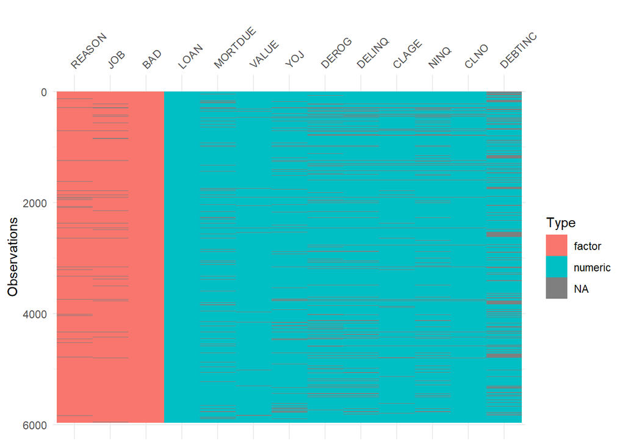

```r
library(visdat)

vis_dat(dataset)
```

# Check the levels of levels of the variable:

```r
#for REASON
dataset %>%
  count(REASON,
        sort = TRUE)
```

| REASON | n |
| --- | --- |
| DebtCon | 3928 |
| HomeImp | 1780 |
| NA | 252 |

```r
# for JOB
dataset %>%
  count(JOB,
        sort = TRUE)
```

| JOB | n |
| --- | --- |
| Other | 2388 |
| ProfExe | 1276 |
| Office | 948 |
| Mgr | 767 |
| NA | 279 |
| Self | 193 |
| Sales | 109 |

#converting character variables to factors

```r
# convert all remaining character variables to factors
dataset <-
  dataset %>%
  mutate(across(where(is.character), as.factor))
```

```r
glimpse(dataset)
```

```
Rows: 5,960
Columns: 13
$ LOAN    <dbl> 1100, 1300, 1500, 1500, 1700, 1700, 1800, 1800, 2000, 2000, 2000, 2000, 2000, 2000, 2100, 2200, 2200, 2200, 2300, 2300, 2300, 2400, 2400, 2400, 2400, 2400, 2400, 2500, 2500, 2500, 2500, 2800, 2800, 2900, 2900, 2900, 2900, 2900, 3000…
$ MORTDUE <dbl> 25860, 70053, 13500, NA, 97800, 30548, 48649, 28502, 32700, NA, 22608, 20627, 45000, 64536, 71000, 24280, 90957, 23030, 28192, 102370, 37626, 50000, 28000, 18000, NA, 34863, 98449, 15000, 25116, 7229, 71408, 50795, 4000, 78600, 1039…
$ VALUE   <dbl> 39025, 68400, 16700, NA, 112000, 40320, 57037, 43034, 46740, 62250, NA, 29800, 55000, 87400, 83850, 34687, 102600, NA, 40150, 120953, 46200, 73395, 40800, NA, 17180, 47471, 117195, 20200, 36350, 44516, 78600, 63100, 60850, 113000, 1…
$ REASON  <fct> HomeImp, HomeImp, HomeImp, NA, HomeImp, HomeImp, HomeImp, HomeImp, HomeImp, HomeImp, NA, HomeImp, HomeImp, NA, HomeImp, HomeImp, HomeImp, NA, HomeImp, HomeImp, HomeImp, HomeImp, HomeImp, HomeImp, HomeImp, HomeImp, HomeImp, HomeImp, …
$ JOB     <fct> Other, Other, Other, NA, Office, Other, Other, Other, Other, Sales, NA, Office, Other, Mgr, Other, Other, Mgr, NA, Other, Office, Other, ProfExe, Mgr, Mgr, Other, Mgr, Office, NA, Other, Self, ProfExe, Self, Other, ProfExe, Office, …
$ YOJ     <dbl> 10.5, 7.0, 4.0, NA, 3.0, 9.0, 5.0, 11.0, 3.0, 16.0, 18.0, 11.0, 3.0, 2.5, 8.0, NA, 7.0, 19.0, 4.5, 2.0, 3.0, 5.0, 12.0, 22.0, NA, 12.0, 4.0, 18.0, 10.0, NA, 8.0, 26.0, 16.0, 6.0, 1.0, 2.0, 16.0, 2.0, 2.0, 3.0, 2.0, 1.0, 8.0, 2.0, 3.…
$ DEROG   <dbl> 0, 0, 0, NA, 0, 0, 3, 0, 0, 0, NA, 0, 0, 0, 0, 0, 2, NA, 0, 0, 0, 1, 0, NA, 0, 0, 0, 0, 1, 0, 0, 2, 4, 1, 0, 0, 3, 0, 0, 0, 0, 0, 0, 0, 0, 0, 0, 0, NA, 0, 0, NA, NA, 0, 0, 0, 0, NA, 1, 0, 0, 0, 0, NA, 0, 0, NA, 0, 1, 0, 0, 1, 0, NA,…
$ DELINQ  <dbl> 0, 2, 0, NA, 0, 0, 2, 0, 2, 0, NA, 1, 0, 0, 1, 1, 6, NA, 0, 0, 1, 0, 0, 2, 0, 0, 0, 0, 2, 0, 0, 15, 0, 0, 0, 0, 0, 0, 0, 0, 1, 1, 0, 0, 0, 0, 1, 2, 2, 0, 0, NA, 1, 4, 0, 0, 0, 2, 0, 6, 1, 0, 0, NA, 0, 0, 2, 0, 4, 0, 0, 6, 0, NA, 0, …
$ CLAGE   <dbl> 94.36667, 121.83333, 149.46667, NA, 93.33333, 101.46600, 77.10000, 88.76603, 216.93333, 115.80000, NA, 122.53333, 86.06667, 147.13333, 123.00000, 300.86667, 122.90000, NA, 54.60000, 90.99253, 122.26667, NA, 67.20000, 121.73333, 14.5…
$ NINQ    <dbl> 1, 0, 1, NA, 0, 1, 1, 0, 1, 0, NA, 1, 2, 0, 0, 0, 1, NA, 1, 0, 1, 1, 2, 0, 3, 1, 0, 1, 0, 0, 0, 3, 2, 2, 0, 0, 2, 3, 0, 5, 0, 1, 0, 0, 14, 0, 5, 0, 0, 0, 1, NA, 0, 1, 0, 3, 0, 0, 0, 0, 0, 0, 0, NA, 2, 1, 0, 0, 0, 0, 1, 1, 0, NA, 0, …
$ CLNO    <dbl> 9, 14, 10, NA, 14, 8, 17, 8, 12, 13, NA, 9, 25, 24, 16, 8, 22, NA, 16, 13, 14, 0, 22, 10, 4, 21, 13, 19, 9, 12, 12, 45, 9, 26, 13, 13, 8, 37, 14, 9, 3, 2, 27, 12, 2, 19, 26, 10, 25, 20, 14, NA, 25, 25, 7, 21, 12, 9, 36, 33, 6, 14, 9…
$ DEBTINC <dbl> NA, NA, NA, NA, NA, 37.1136136, NA, 36.8848941, NA, NA, NA, NA, NA, NA, NA, NA, NA, 3.7113123, NA, 31.5885032, NA, NA, NA, NA, NA, 38.2636007, 29.6818270, NA, NA, NA, NA, NA, NA, NA, 30.0511363, 29.9158590, 36.2113480, 49.2063958, 3…
$ BAD     <fct> 1, 1, 1, 1, 0, 1, 1, 1, 1, 1, 1, 1, 1, 0, 1, 1, 1, 1, 1, 0, 1, 1, 1, 1, 1, 1, 0, 1, 1, 0, 0, 1, 1, 1, 0, 0, 1, 1, 0, 1, 1, 1, 1, 1, 1, 1, 1, 1, 0, 0, 1, 0, 0, 1, 1, 1, 0, 1, 1, 1, 1, 1, 1, 1, 1, 0, 0, 0, 1, 0, 1, 1, 0, 0, 0, 1, 1, 0…
```

#2.Missing data #visualizing missing data

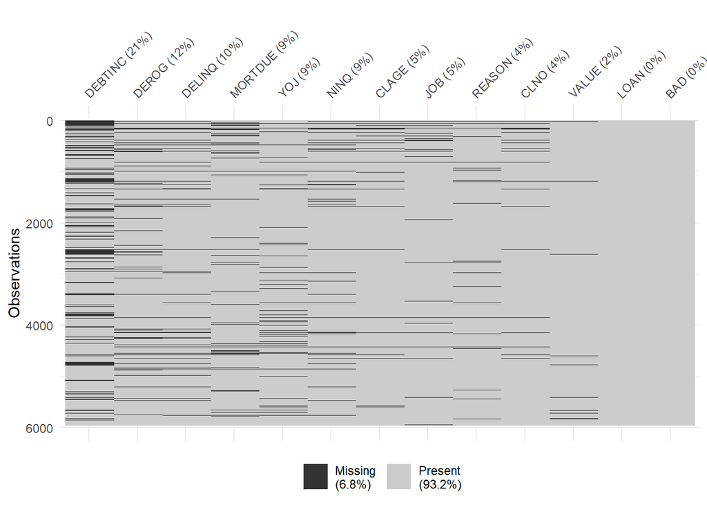

```r
vis_miss(dataset, sort_miss = TRUE)
```

#Viewing missing dataset

```r
is.na(dataset) %>% colSums()
```

```
   LOAN MORTDUE   VALUE  REASON     JOB     YOJ   DEROG  DELINQ   CLAGE    NINQ    CLNO DEBTINC     BAD
      0     518     112     252     279     515     708     580     308     510     222    1267       0
```

# datatype

```r
class(dataset)
```

```
[1] "tbl_df"     "tbl"        "data.frame"
```

```
tbl_df

tbl

data.frame
```

#number of rows and column

```r
dim(dataset)
```

```
[1] 5960   13
```

#3.Get an overview about the complete data

```r
skimr::skim(dataset)
```

Data summary

| Name | dataset |
| --- | --- |
| Number of rows | 5960 |
| Number of columns | 13 |
| _______________________ |  |
| Column type frequency: |  |
| factor | 3 |
| numeric | 10 |
| ________________________ |  |
| Group variables | None |

**Variable type: factor**

| skim_variable | n_missing | complete_rate | ordered | n_unique | top_counts |
| --- | --- | --- | --- | --- | --- |
| REASON | 252 | 0.96 | FALSE | 2 | Deb: 3928, Hom: 1780 |
| JOB | 279 | 0.95 | FALSE | 6 | Oth: 2388, Pro: 1276, Off: 948, Mgr: 767 |
| BAD | 0 | 1.00 | FALSE | 2 | 0: 4771, 1: 1189 |

**Variable type: numeric**

| skim_variable | n_missing | complete_rate | mean | sd | p0 | p25 | p50 | p75 | p100 | hist |
| --- | --- | --- | --- | --- | --- | --- | --- | --- | --- | --- |
| LOAN | 0 | 1.00 | 18607.97 | 11207.48 | 1100.00 | 11100.00 | 16300.00 | 23300.00 | 89900.00 | ▇▅▁▁▁ |
| MORTDUE | 518 | 0.91 | 73760.82 | 44457.61 | 2063.00 | 46276.00 | 65019.00 | 91488.00 | 399550.00 | ▇▃▁▁▁ |
| VALUE | 112 | 0.98 | 101776.05 | 57385.78 | 8000.00 | 66075.50 | 89235.50 | 119824.25 | 855909.00 | ▇▁▁▁▁ |
| YOJ | 515 | 0.91 | 8.92 | 7.57 | 0.00 | 3.00 | 7.00 | 13.00 | 41.00 | ▇▃▂▁▁ |
| DEROG | 708 | 0.88 | 0.25 | 0.85 | 0.00 | 0.00 | 0.00 | 0.00 | 10.00 | ▇▁▁▁▁ |
| DELINQ | 580 | 0.90 | 0.45 | 1.13 | 0.00 | 0.00 | 0.00 | 0.00 | 15.00 | ▇▁▁▁▁ |
| CLAGE | 308 | 0.95 | 179.77 | 85.81 | 0.00 | 115.12 | 173.47 | 231.56 | 1168.23 | ▇▂▁▁▁ |
| NINQ | 510 | 0.91 | 1.19 | 1.73 | 0.00 | 0.00 | 1.00 | 2.00 | 17.00 | ▇▁▁▁▁ |
| CLNO | 222 | 0.96 | 21.30 | 10.14 | 0.00 | 15.00 | 20.00 | 26.00 | 71.00 | ▃▇▂▁▁ |
| DEBTINC | 1267 | 0.79 | 33.78 | 8.60 | 0.52 | 29.14 | 34.82 | 39.00 | 203.31 | ▇▁▁▁▁ |

#A plot of histogram for each numerical attribute as well as correlation coefficients (Pearson is the default)

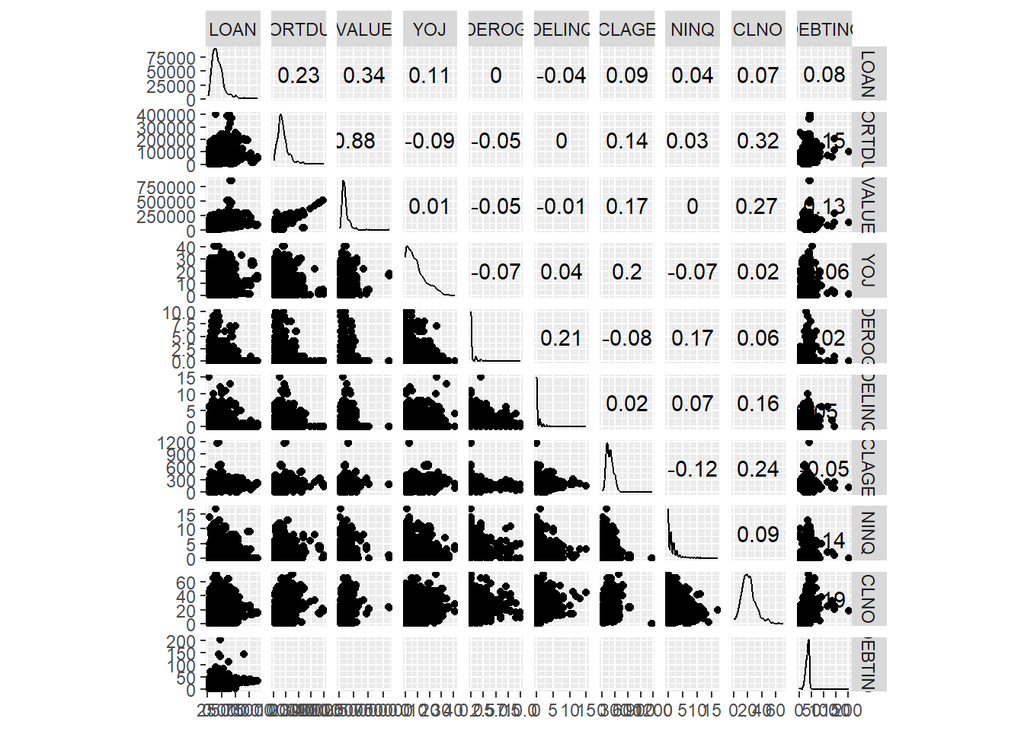

```r
library(GGally)

dataset %>%
  select(BAD,LOAN,MORTDUE,VALUE, YOJ,DEROG, DELINQ,CLAGE,NINQ, CLNO ,DEBTINC
    ) %>%
  ggscatmat(alpha = 1)
```

#3.Get an overview about the complete data

#A plot of histogram for each numerical attribute and categorical variables as well as correlation coefficients (Pearson is the default)

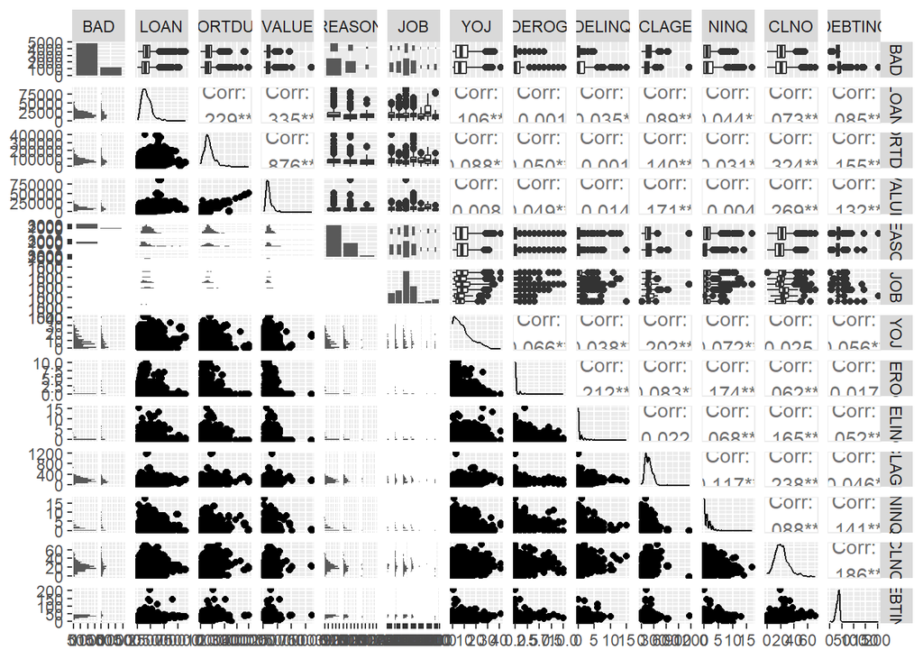

```r
library(GGally)

dataset %>%
  select(BAD,LOAN,MORTDUE,VALUE,REASON,JOB,YOJ,DEROG,DELINQ,CLAGE,NINQ,CLNO,DEBTINC
    ) %>%
  ggpairs()
```

#4.Split data into training and test set using stratified sampling

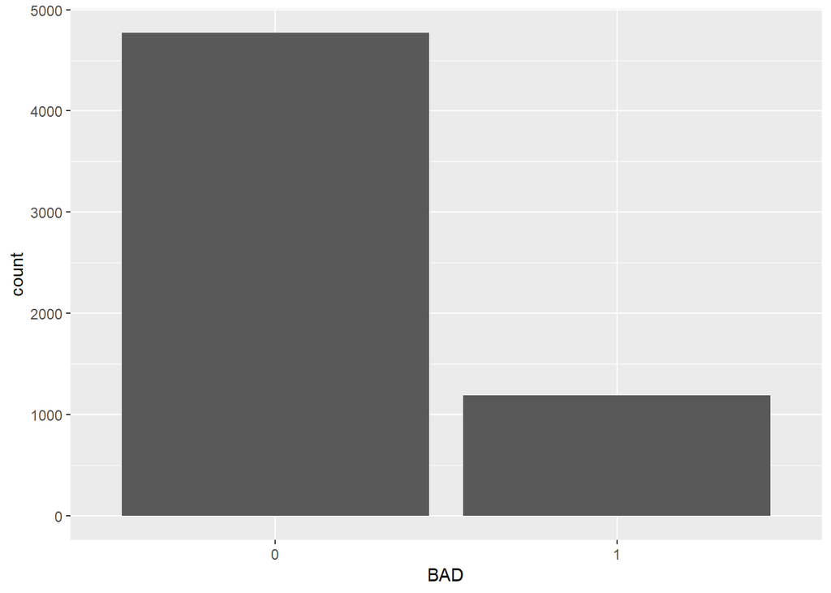

```r
dataset %>%
  ggplot(aes(BAD)) +
  geom_bar()
```

```r
# Fix the random numbers by setting the seed
# This enables the analysis to be reproducible
set.seed(1213)

# Put 3/4 of the data into the training set
data_split <- initial_split(dataset,
                           prop = 3/4,
                           strata = BAD)

# Create dataframes for the two sets:
train_data <- training(data_split)
test_data <- testing(data_split)
```

#5.Visualize the data

#Create data copy

```r
data_explore <- train_data
```

Next, we take a closer look at the relationships between our variables. In particular, we are interested in the relationships between ur dependent variable `BAD` and all other variables. The goal is to identify possible predictor variables which we could use in our models to predict the `BAD`.

#Numerical variables

```r
print_boxplot <- function(.y_var){

  # convert strings to variable
  y_var <- sym(.y_var)

  # unquote variables using {{}}
  data_explore %>%
  ggplot(aes(x = BAD, y = {{y_var}},
             fill = BAD, color = BAD)) + theme_dark()+
  geom_boxplot(alpha=0.4)

}
```

```r
y_var <-
  data_explore %>%
  select(where(is.numeric),-BAD) %>%
  variable.names() # obtain name
```

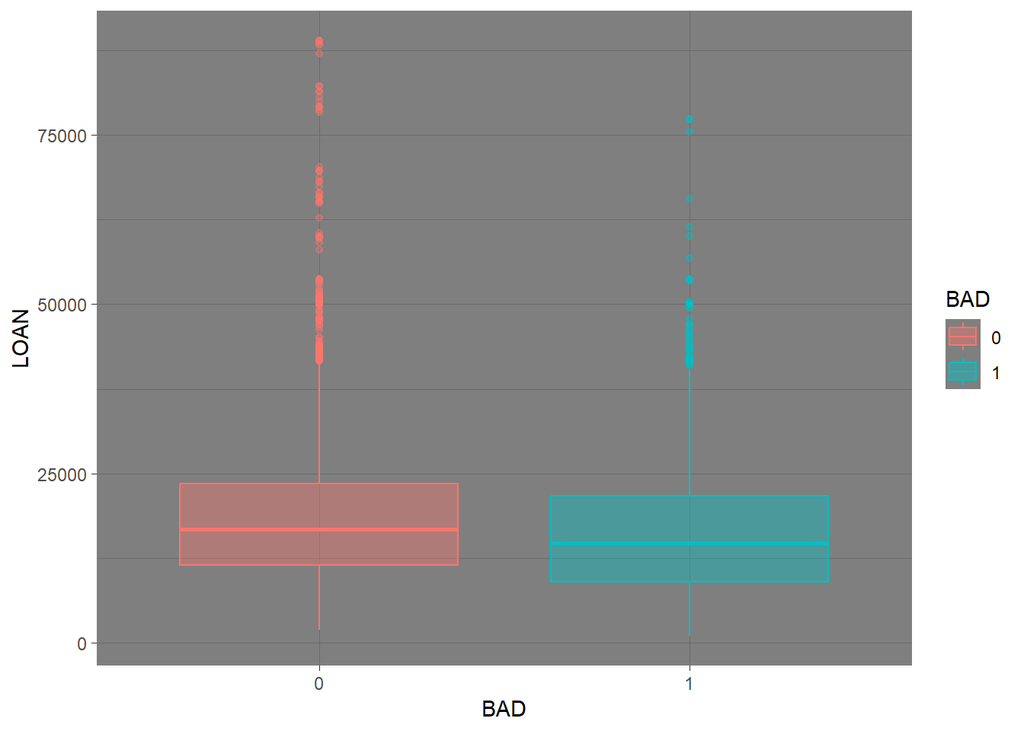

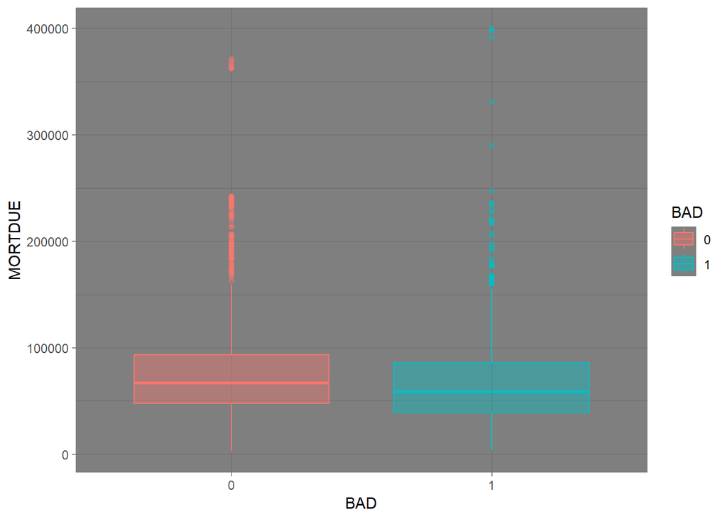

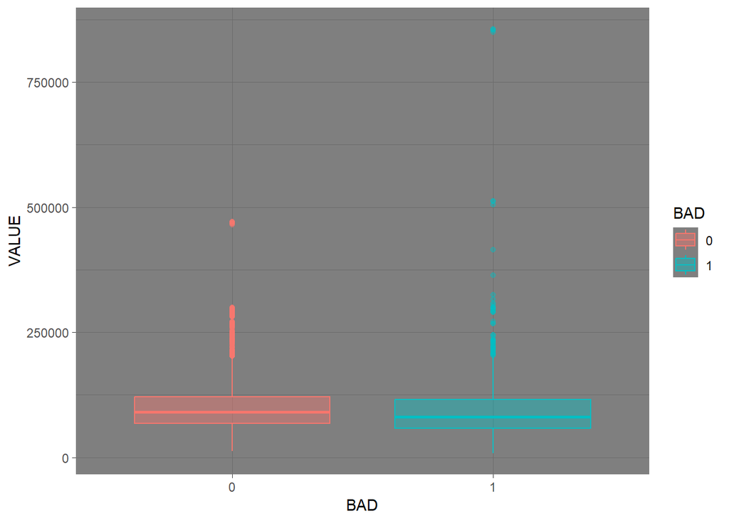

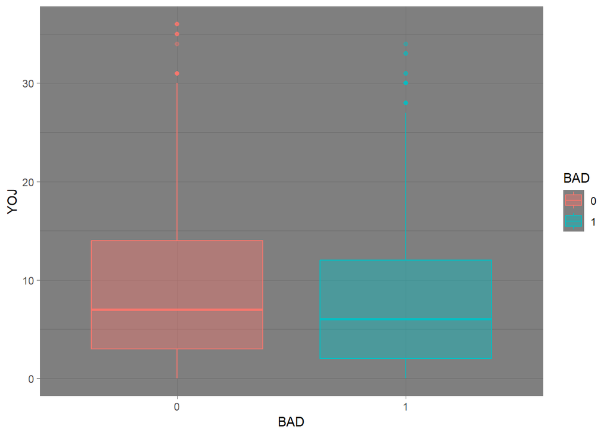

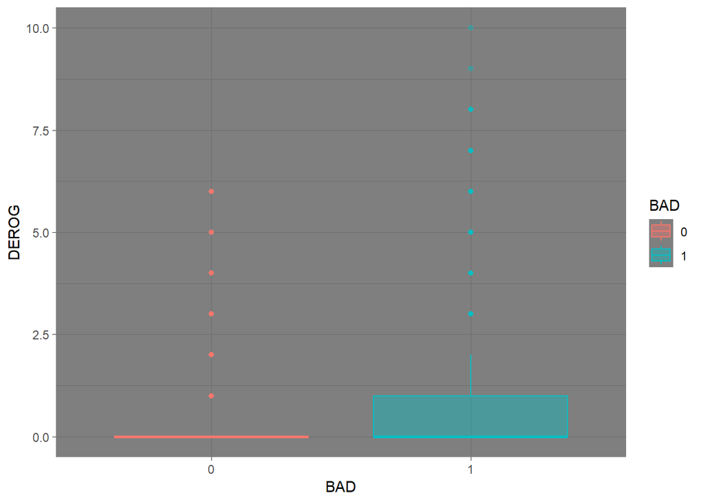

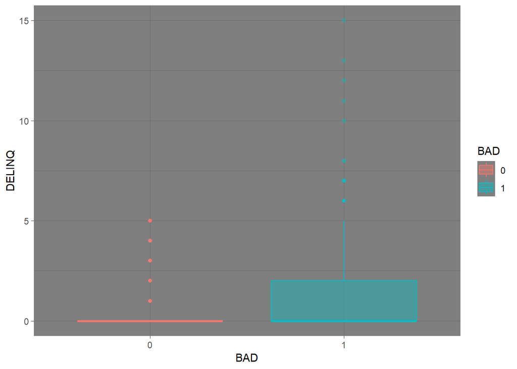

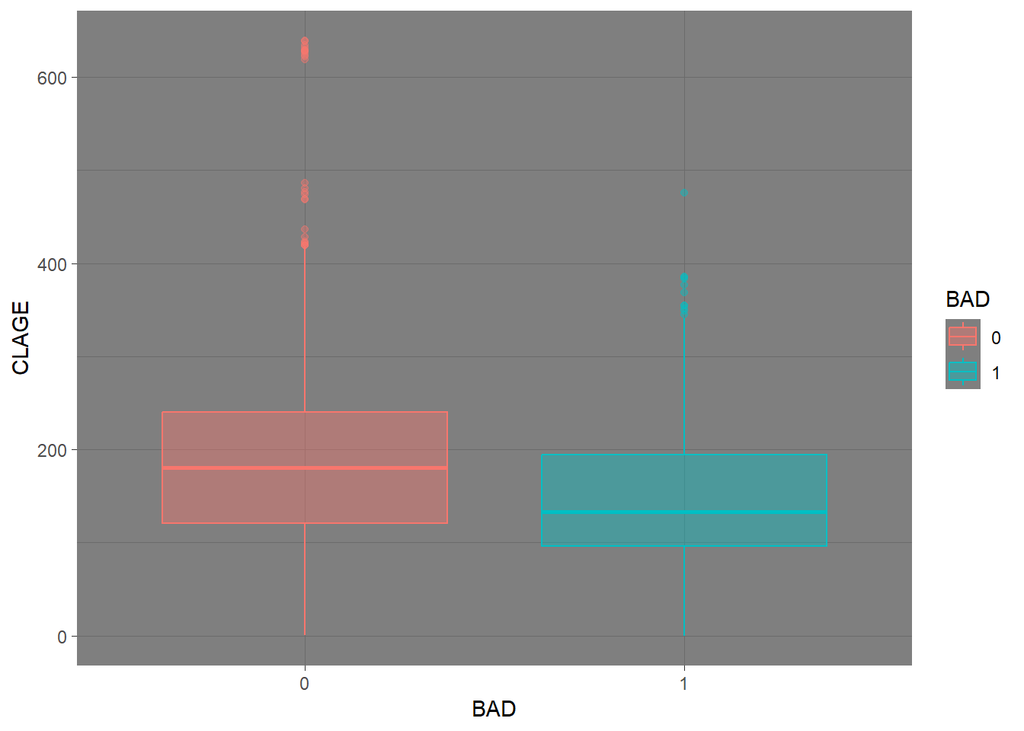

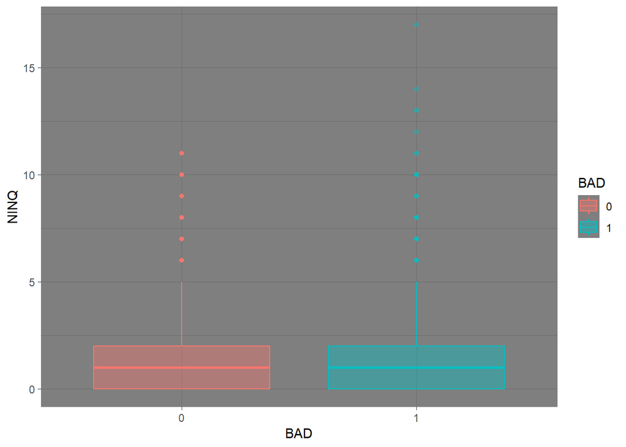

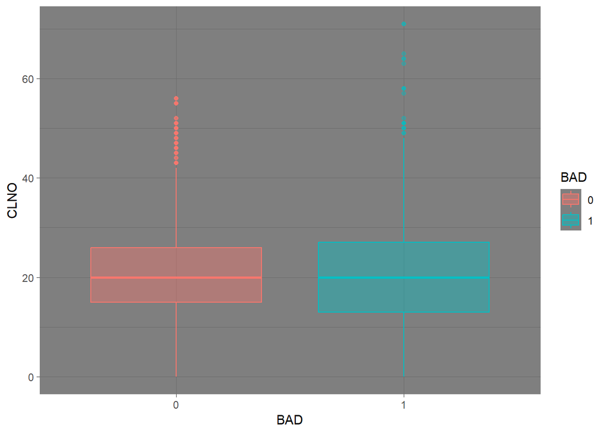

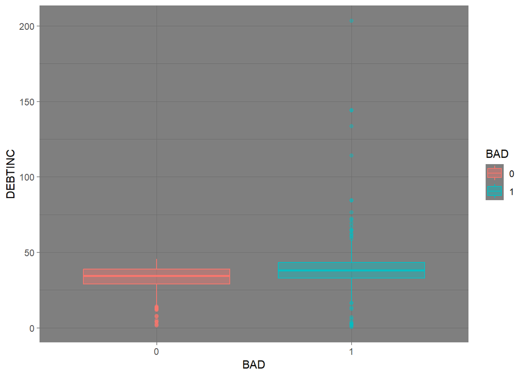

```r
library(purrr)

map(y_var, print_boxplot)
```

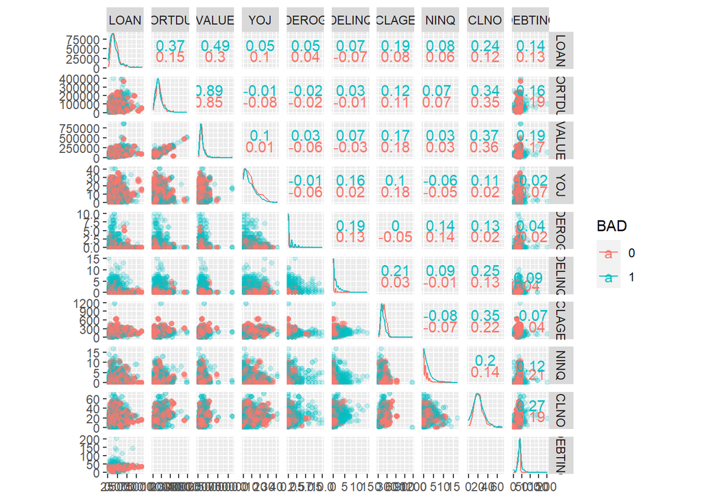

```r
library(GGally)

dataset %>%
  select(BAD,LOAN,MORTDUE,VALUE, YOJ,DEROG, DELINQ,CLAGE,NINQ, CLNO ,DEBTINC
    ) %>%
  ggscatmat(color="BAD",
            corMethod = "spearman",
            alpha=0.2)
```

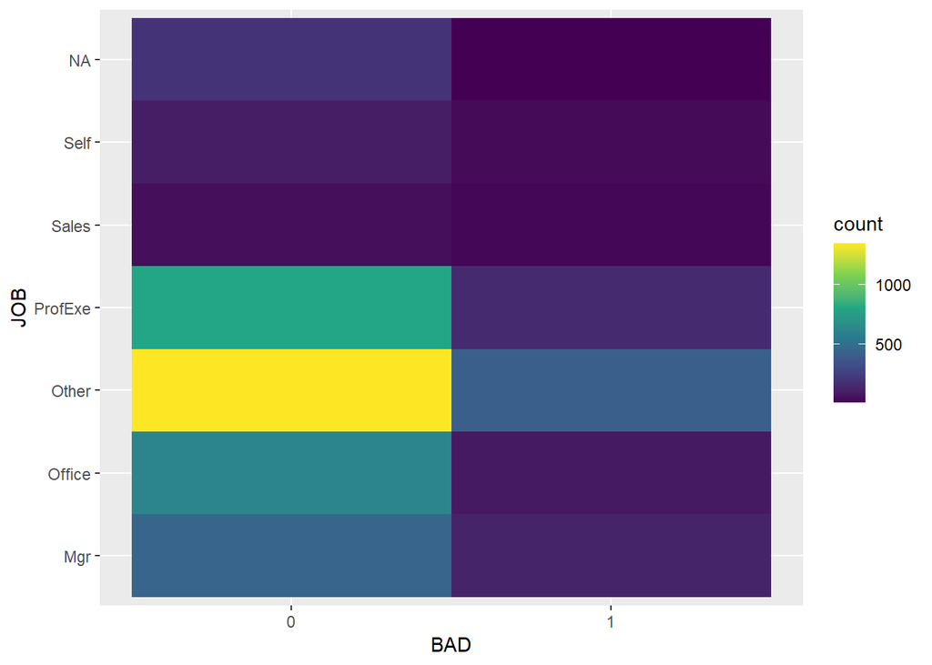

```r
data_explore %>%
  ggplot(aes(BAD, JOB)) + theme_grey()+
  geom_bin2d() +
  scale_fill_continuous(type = "viridis")
```

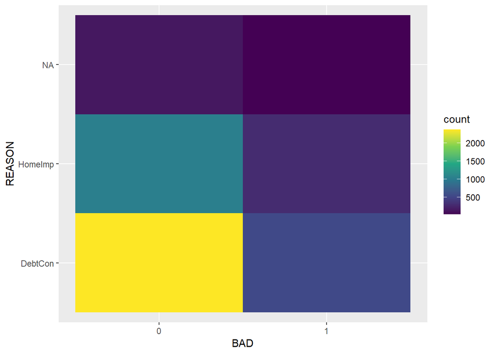

```r
data_explore %>%
  ggplot(aes(BAD, REASON)) + theme_get()+
  geom_bin2d() +
  scale_fill_continuous(type = "viridis")
```

#3 Data preparation Data preparation:

1.Handle missing values 2.Fix or remove outliers 3.Feature selection 4.Feature engineering 5.Feature scaling 6.Create a validation set

```r
dataset_rec <-
  recipe(BAD ~.,
         data = train_data) %>%
  step_log(LOAN,
           MORTDUE,
           VALUE) %>%
   step_impute_mode(REASON,JOB)%>%
   step_impute_mean(LOAN,MORTDUE,VALUE,YOJ,DEROG,DELINQ,CLAGE,NINQ,CLNO,DEBTINC) %>%


  step_naomit(everything(), skip = TRUE) %>%
  step_novel(all_nominal(), -all_outcomes()) %>%
  step_normalize(all_numeric(), -all_outcomes())%>%

  step_dummy(all_nominal(), -all_outcomes()) %>%
  step_zv(all_numeric(), -all_outcomes()) %>%
  step_corr(all_predictors(), threshold = 0.7, method = "spearman")
```

```r
summary(dataset_rec)
```

| variable | type | role | source |
| --- | --- | --- | --- |
| LOAN |  | predictor | original |
| MORTDUE |  | predictor | original |
| VALUE |  | predictor | original |
| REASON |  | predictor | original |
| JOB |  | predictor | original |
| YOJ |  | predictor | original |
| DEROG |  | predictor | original |
| DELINQ |  | predictor | original |
| CLAGE |  | predictor | original |
| NINQ |  | predictor | original |

[output cut: 3 more lines]

```r
prepped_data <-
  dataset_rec %>% # use the recipe object
  prep() %>% # perform the recipe on training data
  juice() # extract only the preprocessed dataframe
```

```r
glimpse(prepped_data)
```

```
Rows: 4,469
Columns: 16
$ LOAN           <dbl> -3.574075, -3.332052, -3.258353, -3.187662, -3.187662, -2.930646, -2.930646, -2.871940, -2.871940, -2.871940, -2.815158, -2.760180, -2.556218, -2.556218, -2.556218, -2.462590, -2.462590, -2.417609, -2.373767, -2.373767, -2.37…
$ MORTDUE        <dbl> 0.075862121, 0.826318268, 0.762792088, -3.484921359, 0.240450412, 0.851215833, 0.857837035, 0.860904248, -0.097824442, -0.439886807, 0.000000000, 0.317327844, 0.498798645, -0.007098361, -0.264938377, -0.301300168, -2.72371679…
$ YOJ            <dbl> -0.890874270, -0.959642499, -0.684569584, 0.000000000, -0.134423755, -1.097178956, -0.959642499, -0.959642499, 0.140649160, 1.653550190, 0.000000000, -0.271960212, -0.409496669, 0.003112703, 1.516013733, 1.516013733, 0.000000…
$ DEROG          <dbl> -0.322463, -0.322463, -0.322463, -0.322463, -0.322463, -0.322463, -0.322463, -0.322463, 0.000000, -0.322463, 0.000000, -0.322463, -0.322463, 0.000000, -0.322463, -0.322463, -0.322463, -0.322463, -0.322463, -0.322463, 2.171547…
$ DELINQ         <dbl> -0.4179079, -0.4179079, -0.4179079, -0.4179079, -0.4179079, -0.4179079, -0.4179079, -0.4179079, 1.4597708, -0.4179079, 0.0000000, -0.4179079, -0.4179079, 1.4597708, -0.4179079, -0.4179079, -0.4179079, -0.4179079, -0.4179079, …
$ CLAGE          <dbl> -0.401128051, -1.091996571, -1.057302995, 0.347896972, 0.935303233, -1.029115434, -0.962195817, -1.154857592, 0.396300560, 0.272420190, 0.000000000, 0.872517247, 0.160025416, 0.280346587, 0.302026353, 0.295615356, 0.306647167…
$ NINQ           <dbl> -0.7096663, -0.7096663, -0.7096663, -0.7096663, -0.7096663, -0.7096663, -0.7096663, -0.7096663, -0.7096663, -0.7096663, 0.0000000, -0.7096663, -0.1022086, -0.7096663, -0.7096663, -0.7096663, -0.7096663, -0.7096663, -0.7096663…
$ CLNO           <dbl> 0.26754156, -0.84147722, -0.84147722, -0.94229710, -0.94229710, -0.84147722, -0.84147722, -0.74065733, 0.36836145, -0.13573800, 0.00000000, -0.94229710, 0.67082111, 0.36836145, -0.13573800, -0.13573800, -1.04311699, -0.841477…
$ DEBTINC        <dbl> 0.00000000, -0.29003644, -0.53406418, 0.00000000, 0.00000000, -0.48679779, -0.50411137, -0.22971922, 0.00000000, 0.00000000, 0.00000000, 1.15895562, 0.00000000, 0.98059344, -1.71293134, -1.76462146, 1.06465156, -0.57731139, -…
$ BAD            <fct> 0, 0, 0, 0, 0, 0, 0, 0, 0, 0, 0, 0, 0, 0, 0, 0, 0, 0, 0, 0, 0, 0, 0, 0, 0, 0, 0, 0, 0, 0, 0, 0, 0, 0, 0, 0, 0, 0, 0, 0, 0, 0, 0, 0, 0, 0, 0, 0, 0, 0, 0, 0, 0, 0, 0, 0, 0, 0, 0, 0, 0, 0, 0, 0, 0, 0, 0, 0, 0, 0, 0, 0, 0, 0, 0, …
$ REASON_HomeImp <dbl> 0, 1, 1, 1, 1, 1, 1, 1, 1, 1, 0, 1, 1, 1, 1, 1, 1, 1, 1, 1, 1, 1, 1, 1, 1, 1, 0, 1, 0, 0, 1, 0, 1, 1, 0, 1, 0, 1, 1, 0, 1, 0, 1, 0, 0, 1, 0, 0, 1, 0, 1, 0, 1, 1, 0, 0, 0, 1, 0, 0, 1, 0, 0, 0, 1, 1, 1, 1, 0, 1, 0, 1, 1, 0, 1, …
$ JOB_Office     <dbl> 0, 1, 1, 0, 0, 1, 1, 1, 0, 1, 0, 0, 0, 0, 1, 1, 0, 1, 1, 1, 0, 0, 0, 0, 0, 0, 0, 1, 0, 0, 1, 0, 0, 0, 0, 0, 0, 0, 0, 0, 0, 0, 0, 0, 0, 0, 0, 0, 0, 0, 0, 0, 0, 1, 0, 0, 0, 1, 0, 0, 1, 0, 0, 0, 0, 0, 0, 0, 0, 0, 0, 0, 0, 0, 0, …
$ JOB_Other      <dbl> 0, 0, 0, 0, 0, 0, 0, 0, 0, 0, 1, 0, 0, 0, 0, 0, 0, 0, 0, 0, 1, 1, 1, 0, 0, 0, 0, 0, 0, 1, 0, 0, 1, 1, 0, 1, 1, 1, 1, 0, 1, 1, 0, 0, 0, 1, 0, 0, 1, 1, 1, 0, 0, 0, 1, 1, 0, 0, 0, 0, 0, 1, 0, 1, 1, 1, 0, 1, 1, 0, 1, 1, 1, 1, 1, …
$ JOB_ProfExe    <dbl> 0, 0, 0, 0, 1, 0, 0, 0, 0, 0, 0, 1, 1, 0, 0, 0, 0, 0, 0, 0, 0, 0, 0, 0, 0, 0, 1, 0, 0, 0, 0, 0, 0, 0, 1, 0, 0, 0, 0, 0, 0, 0, 1, 1, 0, 0, 0, 1, 0, 0, 0, 0, 1, 0, 0, 0, 1, 0, 1, 1, 0, 0, 0, 0, 0, 0, 1, 0, 0, 1, 0, 0, 0, 0, 0, …
$ JOB_Sales      <dbl> 0, 0, 0, 0, 0, 0, 0, 0, 0, 0, 0, 0, 0, 0, 0, 0, 0, 0, 0, 0, 0, 0, 0, 1, 0, 0, 0, 0, 1, 0, 0, 1, 0, 0, 0, 0, 0, 0, 0, 0, 0, 0, 0, 0, 0, 0, 1, 0, 0, 0, 0, 0, 0, 0, 0, 0, 0, 0, 0, 0, 0, 0, 0, 0, 0, 0, 0, 0, 0, 0, 0, 0, 0, 0, 0, …
$ JOB_Self       <dbl> 0, 0, 0, 1, 0, 0, 0, 0, 0, 0, 0, 0, 0, 0, 0, 0, 1, 0, 0, 0, 0, 0, 0, 0, 0, 0, 0, 0, 0, 0, 0, 0, 0, 0, 0, 0, 0, 0, 0, 0, 0, 0, 0, 0, 0, 0, 0, 0, 0, 0, 0, 0, 0, 0, 0, 0, 0, 0, 0, 0, 0, 0, 0, 0, 0, 0, 0, 0, 0, 0, 0, 0, 0, 0, 0, …
```

```r
#check missing data
sum(is.na(prepped_data))
```

```
[1] 0
```

```r
set.seed(1001)

cv_folds <-
 vfold_cv(train_data,
          v = 5,
          strata = BAD)
```

#4.*Logistic regression*

#Specify model

```r
log_spec <- # your model specification
  logistic_reg() %>%  # model type
  set_engine(engine = "glm") %>%  # model engine
  set_mode("classification") # model mode

# Show your model specification
log_spec
```

```
Logistic Regression Model Specification (classification)

Computational engine: glm
```

#Creating Workflow

```r
log_wflow <- # new workflow object
 workflow() %>% # use workflow function
 add_recipe(dataset_rec) %>%   # use the new recipe
 add_model(log_spec)   # add your model spec

# show object
log_wflow
```

```
══ Workflow ══════════════════════════════════════════════════════════════════════════════════════════════════════════════════════════════════════════════════════════════════════════════════════════════════════════════════════════════════════════════
Preprocessor: Recipe
Model: logistic_reg()

── Preprocessor ──────────────────────────────────────────────────────────────────────────────────────────────────────────────────────────────────────────────────────────────────────────────────────────────────────────────────────────────────────────
9 Recipe Steps

• step_log()
• step_impute_mode()
• step_impute_mean()
• step_naomit()
• step_novel()
• step_normalize()
• step_dummy()
• step_zv()
• step_corr()

── Model ─────────────────────────────────────────────────────────────────────────────────────────────────────────────────────────────────────────────────────────────────────────────────────────────────────────────────────────────────────────────────
Logistic Regression Model Specification (classification)

Computational engine: glm
```

```r
log_res <-
  log_wflow %>%
  fit_resamples(
    resamples = cv_folds,
    metrics = metric_set(
      recall, precision, f_meas,
      accuracy, kap,
      roc_auc, sens, spec),
    control = control_resamples(
      save_pred = TRUE)
    )
```

```r
# save model coefficients for a fitted model object from a workflow

get_model <- function(x) {
  pull_workflow_fit(x) %>% tidy()
}

# same as before with one exception
log_res_2 <-
  log_wflow %>%
  fit_resamples(
    resamples = cv_folds,
    metrics = metric_set(
      recall, precision, f_meas,
      accuracy, kap,
      roc_auc, sens, spec),
    control = control_resamples(
      save_pred = TRUE,
      extract = get_model) # use extract and our new function
    )
```

#Evaluate model

```r
all_coef <- map_dfr(log_res_2$.extracts, ~ .x[[1]][[1]])
```

```r
filter(all_coef, term == "DEROG")
```

| term | estimate | std.error | statistic | p.value |
| --- | --- | --- | --- | --- |
| DEROG | 0.4330777 | 0.05014525 | 8.636466 | 0.0000000000000000057978639 |
| DEROG | 0.3694685 | 0.04613701 | 8.008072 | 0.0000000000000011652081946 |
| DEROG | 0.4544167 | 0.05038585 | 9.018736 | 0.0000000000000000001902712 |
| DEROG | 0.4348979 | 0.04888792 | 8.895815 | 0.0000000000000000005799225 |
| DEROG | 0.3424362 | 0.04528427 | 7.561925 | 0.0000000000000397146922393 |

#Performance metrics ##Show average performance over all folds

```r
log_res %>%  collect_metrics(summarize = TRUE)
```

| .metric | .estimator | mean | n | std_err | .config |
| --- | --- | --- | --- | --- | --- |
| accuracy | binary | 0.8324001 | 5 | 0.004095482 | Preprocessor1_Model1 |
| f_meas | binary | 0.9023025 | 5 | 0.002444013 | Preprocessor1_Model1 |
| kap | binary | 0.3310572 | 5 | 0.014788470 | Preprocessor1_Model1 |
| precision | binary | 0.8459209 | 5 | 0.001990410 | Preprocessor1_Model1 |
| recall | binary | 0.9667395 | 5 | 0.003079144 | Preprocessor1_Model1 |
| roc_auc | binary | 0.7922378 | 5 | 0.009402983 | Preprocessor1_Model1 |
| sens | binary | 0.9667395 | 5 | 0.003079144 | Preprocessor1_Model1 |
| spec | binary | 0.2929383 | 5 | 0.008289967 | Preprocessor1_Model1 |

##Show performance for every single fold:

```r
log_res %>%  collect_metrics(summarize = FALSE)
```

| id | .metric | .estimator | .estimate | .config |
| --- | --- | --- | --- | --- |
| Fold1 | recall | binary | 0.9608939 | Preprocessor1_Model1 |
| Fold1 | precision | binary | 0.8431373 | Preprocessor1_Model1 |
| Fold1 | f_meas | binary | 0.8981723 | Preprocessor1_Model1 |
| Fold1 | accuracy | binary | 0.8256983 | Preprocessor1_Model1 |
| Fold1 | kap | binary | 0.3109541 | Preprocessor1_Model1 |
| Fold1 | sens | binary | 0.9608939 | Preprocessor1_Model1 |
| Fold1 | spec | binary | 0.2849162 | Preprocessor1_Model1 |
| Fold1 | roc_auc | binary | 0.7648013 | Preprocessor1_Model1 |
| Fold2 | recall | binary | 0.9734637 | Preprocessor1_Model1 |
| Fold2 | precision | binary | 0.8510379 | Preprocessor1_Model1 |

[output cut: 30 more lines]

#Collect predictions

```r
#our prediction saved as log_pred
log_pred <-
  log_res %>%
  #function to collect obtain the actual model predictions
  collect_predictions()
```

##Confusion matrix

```r
log_pred %>%
  conf_mat(BAD, .pred_class)
```

```
          Truth
Prediction    0    1
         0 3459  630
         1  119  261
```

##A quick visualizion of our confusion matrix

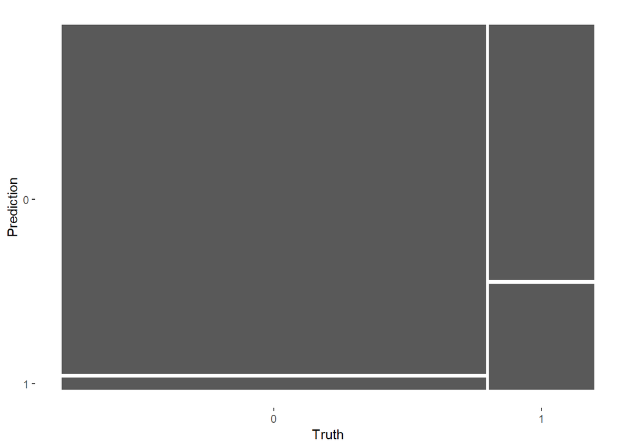

```r
log_pred %>%
  conf_mat(BAD, .pred_class) %>%
  autoplot(type = "mosaic")
```

## Heatmap of our confusion matrix

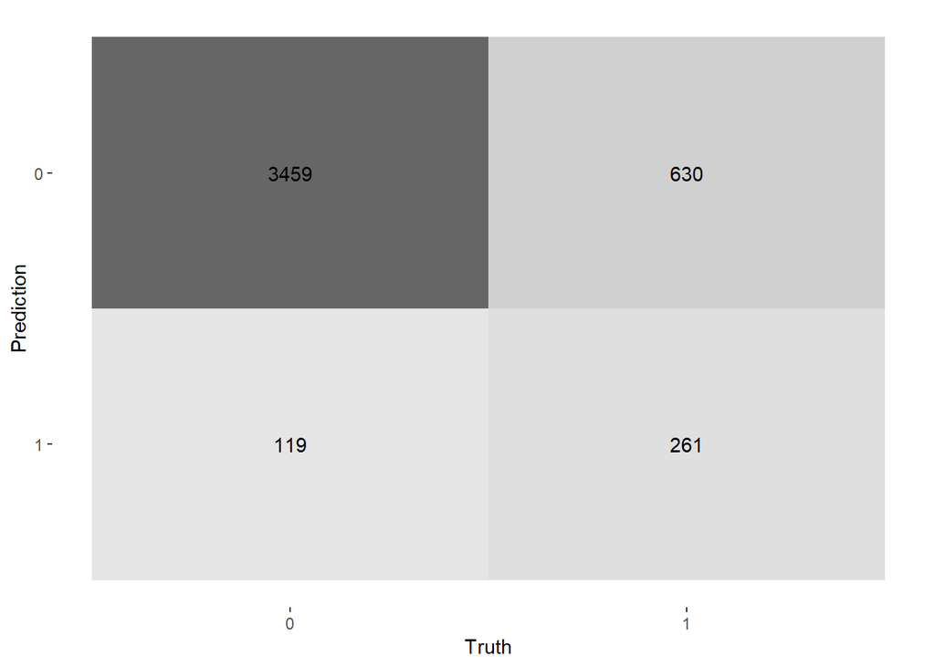

```r
log_pred %>%
  conf_mat(BAD, .pred_class) %>%
  autoplot(type = "heatmap")
```

```r
head(log_pred)
```

| id | .pred_class | .row | .pred_0 | .pred_1 | BAD | .config |
| --- | --- | --- | --- | --- | --- | --- |
| Fold1 | 0 | 5 | 0.8121919 | 0.1878081 | 0 | Preprocessor1_Model1 |
| Fold1 | 0 | 10 | 0.8919550 | 0.1080450 | 0 | Preprocessor1_Model1 |
| Fold1 | 0 | 11 | 0.7272738 | 0.2727262 | 0 | Preprocessor1_Model1 |
| Fold1 | 0 | 12 | 0.7415232 | 0.2584768 | 0 | Preprocessor1_Model1 |
| Fold1 | 0 | 13 | 0.7833562 | 0.2166438 | 0 | Preprocessor1_Model1 |
| Fold1 | 1 | 14 | 0.3980275 | 0.6019725 | 0 | Preprocessor1_Model1 |

##ROC-Curve ROC curve for our 5 folds

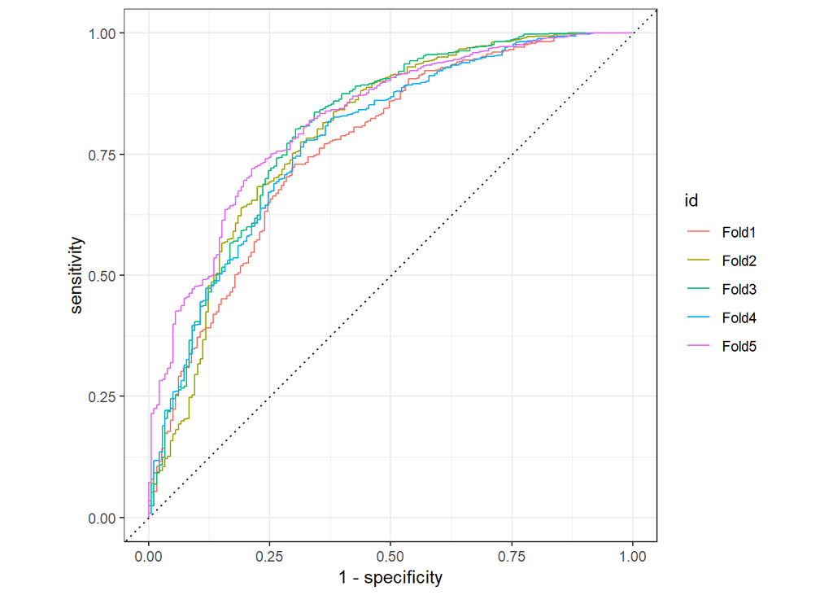

```r
log_pred %>%
  group_by(id) %>% # id contains our folds
  roc_curve(BAD, .pred_0) %>%
  autoplot()
```

#Probability distributions Plot predicted probability distributions for our two classes.

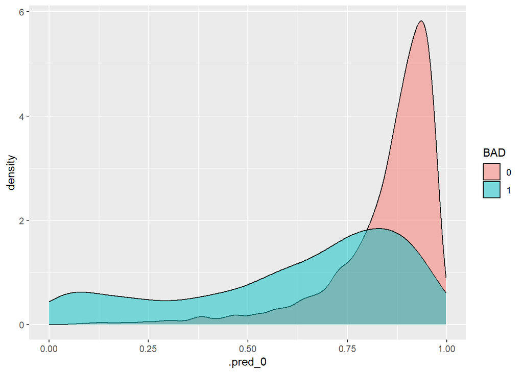

```r
log_pred %>%
  ggplot() +
  geom_density(aes(x = .pred_0,
                   fill = BAD),
               alpha = 0.5)
```

#5. Random forest

##Specify models

```r
library(ranger)

rf_spec <-
  rand_forest() %>%
  set_engine("ranger", importance = "impurity") %>%
  set_mode("classification")
```

##Bundle recipe and model:

```r
rf_wflow <-
 workflow() %>%
 add_recipe(dataset_rec) %>%
 add_model(rf_spec)
```

##performance metrics.

```r
rf_res <-
  rf_wflow %>%
  fit_resamples(
    resamples = cv_folds,
    metrics = metric_set(
      recall, precision, f_meas,
      accuracy, kap,
      roc_auc, sens, spec),
    control = control_resamples(save_pred = TRUE)
    )

rf_res %>%  collect_metrics(summarize = TRUE)
```

| .metric | .estimator | mean | n | std_err | .config |
| --- | --- | --- | --- | --- | --- |
| accuracy | binary | 0.9136249 | 5 | 0.003990042 | Preprocessor1_Model1 |
| f_meas | binary | 0.9477389 | 5 | 0.002339446 | Preprocessor1_Model1 |
| kap | binary | 0.7002601 | 5 | 0.015426586 | Preprocessor1_Model1 |
| precision | binary | 0.9194134 | 5 | 0.004187395 | Preprocessor1_Model1 |
| recall | binary | 0.9779193 | 5 | 0.002094240 | Preprocessor1_Model1 |
| roc_auc | binary | 0.9605494 | 5 | 0.002498766 | Preprocessor1_Model1 |
| sens | binary | 0.9779193 | 5 | 0.002094240 | Preprocessor1_Model1 |
| spec | binary | 0.6554454 | 5 | 0.019252553 | Preprocessor1_Model1 |

##Model coefficients

```r
# save model coefficients for a fitted model object from a workflow

get_model <- function(x) {
  pull_workflow_fit(x) %>% tidy()
}

# same as before with one exception
rf_res_2 <-
  rf_wflow %>%
  fit_resamples(
    resamples = cv_folds,
    metrics = metric_set(
      recall, precision, f_meas,
      accuracy, kap,
      roc_auc, sens, spec),
    control = control_resamples(
      save_pred = TRUE,
      extract = get_model) # use extract and our new function
    )
```

##Performance metrics

###Show average performance over all folds

```r
rf_res %>%  collect_metrics(summarize = TRUE)
```

| .metric | .estimator | mean | n | std_err | .config |
| --- | --- | --- | --- | --- | --- |
| accuracy | binary | 0.9136249 | 5 | 0.003990042 | Preprocessor1_Model1 |
| f_meas | binary | 0.9477389 | 5 | 0.002339446 | Preprocessor1_Model1 |
| kap | binary | 0.7002601 | 5 | 0.015426586 | Preprocessor1_Model1 |
| precision | binary | 0.9194134 | 5 | 0.004187395 | Preprocessor1_Model1 |
| recall | binary | 0.9779193 | 5 | 0.002094240 | Preprocessor1_Model1 |
| roc_auc | binary | 0.9605494 | 5 | 0.002498766 | Preprocessor1_Model1 |
| sens | binary | 0.9779193 | 5 | 0.002094240 | Preprocessor1_Model1 |
| spec | binary | 0.6554454 | 5 | 0.019252553 | Preprocessor1_Model1 |

###Show performance for every single fold:

```r
rf_res %>%  collect_metrics(summarize = FALSE)
```

| id | .metric | .estimator | .estimate | .config |
| --- | --- | --- | --- | --- |
| Fold1 | recall | binary | 0.9748603 | Preprocessor1_Model1 |
| Fold1 | precision | binary | 0.9184211 | Preprocessor1_Model1 |
| Fold1 | f_meas | binary | 0.9457995 | Preprocessor1_Model1 |
| Fold1 | accuracy | binary | 0.9106145 | Preprocessor1_Model1 |
| Fold1 | kap | binary | 0.6923077 | Preprocessor1_Model1 |
| Fold1 | sens | binary | 0.9748603 | Preprocessor1_Model1 |
| Fold1 | spec | binary | 0.6536313 | Preprocessor1_Model1 |
| Fold1 | roc_auc | binary | 0.9508910 | Preprocessor1_Model1 |
| Fold2 | recall | binary | 0.9860335 | Preprocessor1_Model1 |
| Fold2 | precision | binary | 0.9145078 | Preprocessor1_Model1 |

[output cut: 30 more lines]

####Collect predictions

```r
rf_pred <-
  rf_res %>%
  collect_predictions()
```

####Confusion matrix

```r
rf_pred %>%
  conf_mat(BAD, .pred_class)
```

```
          Truth
Prediction    0    1
         0 3499  307
         1   79  584
```

###Quick visualization confusion matrix

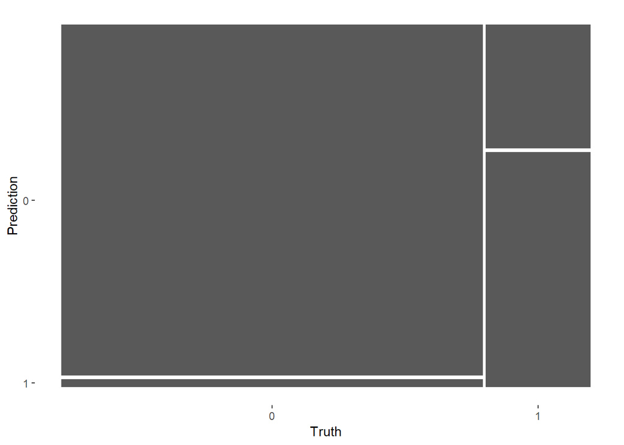

```r
rf_pred %>%
  conf_mat(BAD, .pred_class) %>%
  autoplot(type = "mosaic")
```

####Confusion matrix Heatmap

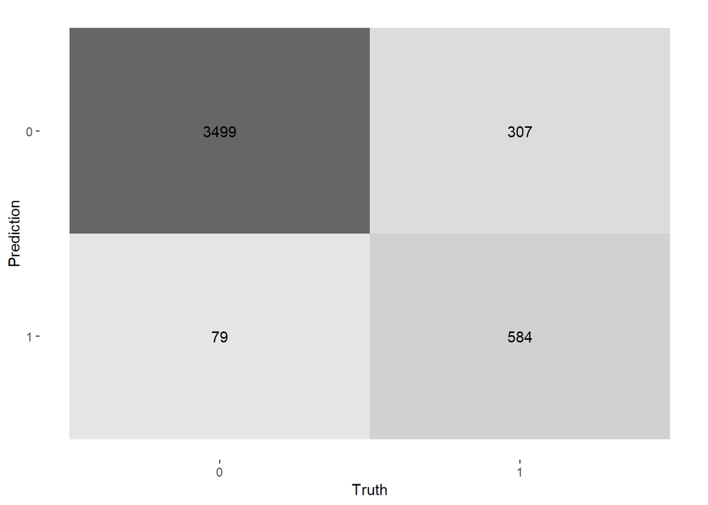

```r
rf_pred %>%
  conf_mat(BAD, .pred_class) %>%
  autoplot(type = "heatmap")
```

###ROC-Curve ROC curve for our 5 folds

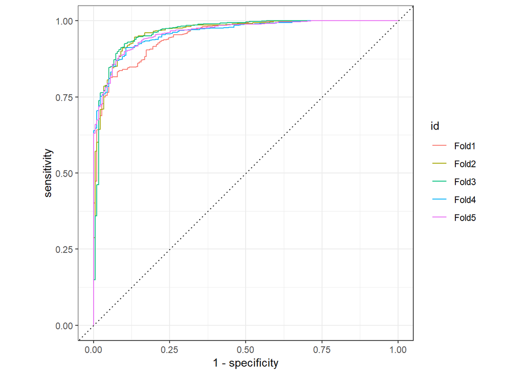

```r
rf_pred %>%
  group_by(id) %>% # id contains our folds
  roc_curve(BAD, .pred_0) %>%
  autoplot()
```

###Probability distributions

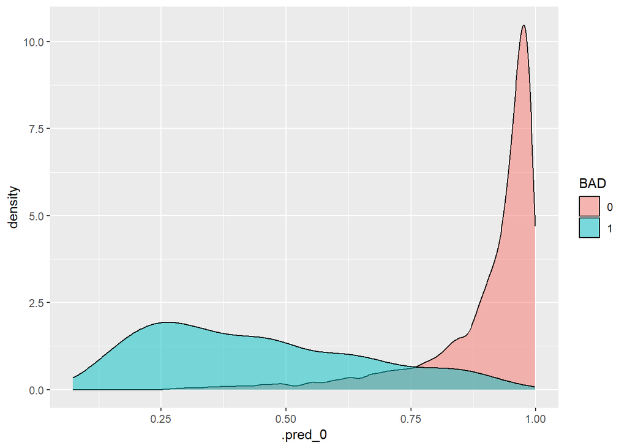

```r
rf_pred %>%
  ggplot() +
  geom_density(aes(x = .pred_0,
                   fill = BAD),
               alpha = 0.5)
```

#6:XGBoost ##Boosted tree (XGBoost) #specify model

```r
library(xgboost)

xgb_spec <-
  boost_tree() %>%
  set_engine("xgboost") %>%
  set_mode("classification")
```

#Bundle recipe and model with workflows:

```r
xgb_wflow <-
 workflow() %>%
 add_recipe(dataset_rec) %>%
 add_model(xgb_spec)
```

```r
xgb_res <-
  xgb_wflow %>%
  fit_resamples(
    resamples = cv_folds,
    metrics = metric_set(
      recall, precision, f_meas,
      accuracy, kap,
      roc_auc, sens, spec),
    control = control_resamples(
      save_pred = TRUE)
    )
```

##metrics

```r
xgb_res <-
  xgb_wflow %>%
  fit_resamples(
    resamples = cv_folds,
    metrics = metric_set(
      recall, precision, f_meas,
      accuracy, kap,
      roc_auc, sens, spec),
    control = control_resamples(save_pred = TRUE)
    )

xgb_res %>% collect_metrics(summarize = TRUE)
```

| .metric | .estimator | mean | n | std_err | .config |
| --- | --- | --- | --- | --- | --- |
| accuracy | binary | 0.9022138 | 5 | 0.003147905 | Preprocessor1_Model1 |
| f_meas | binary | 0.9402381 | 5 | 0.001832169 | Preprocessor1_Model1 |
| kap | binary | 0.6720089 | 5 | 0.012255403 | Preprocessor1_Model1 |
| precision | binary | 0.9207568 | 5 | 0.003468888 | Preprocessor1_Model1 |
| recall | binary | 0.9605926 | 5 | 0.001025187 | Preprocessor1_Model1 |
| roc_auc | binary | 0.9324430 | 5 | 0.004959886 | Preprocessor1_Model1 |
| sens | binary | 0.9605926 | 5 | 0.001025187 | Preprocessor1_Model1 |
| spec | binary | 0.6677986 | 5 | 0.015572345 | Preprocessor1_Model1 |

#7:K-nearest neighbor

# Specify model

```r
knn_spec <-
  nearest_neighbor(neighbors = 4) %>% # we can adjust the number of neighbors
  set_engine("kknn") %>%
  set_mode("classification")
```

#Bundle recipe and model with workflows:

```r
knn_wflow <-
 workflow() %>%
 add_recipe(dataset_rec) %>%
 add_model(knn_spec)
```

```r
knn_res <-
  knn_wflow %>%
  fit_resamples(
    resamples = cv_folds,
    metrics = metric_set(
      recall, precision, f_meas,
      accuracy, kap,
      roc_auc, sens, spec),
    control = control_resamples(
      save_pred = TRUE)
    )
```

```r
knn_res <-
  knn_wflow %>%
  fit_resamples(
    resamples = cv_folds,
    metrics = metric_set(
      recall, precision, f_meas,
      accuracy, kap,
      roc_auc, sens, spec),
    control = control_resamples(save_pred = TRUE)
    )

knn_res %>% collect_metrics(summarize = TRUE)
```

| .metric | .estimator | mean | n | std_err | .config |
| --- | --- | --- | --- | --- | --- |
| accuracy | binary | 0.9254895 | 5 | 0.004646888 | Preprocessor1_Model1 |
| f_meas | binary | 0.9552008 | 5 | 0.002694755 | Preprocessor1_Model1 |
| kap | binary | 0.7356158 | 5 | 0.018728492 | Preprocessor1_Model1 |
| precision | binary | 0.9214361 | 5 | 0.004964680 | Preprocessor1_Model1 |
| recall | binary | 0.9916127 | 5 | 0.002212681 | Preprocessor1_Model1 |
| roc_auc | binary | 0.8872968 | 5 | 0.009072453 | Preprocessor1_Model1 |
| sens | binary | 0.9916127 | 5 | 0.002212681 | Preprocessor1_Model1 |
| spec | binary | 0.6600151 | 5 | 0.023240283 | Preprocessor1_Model1 |

ROC curve for our 5 folds

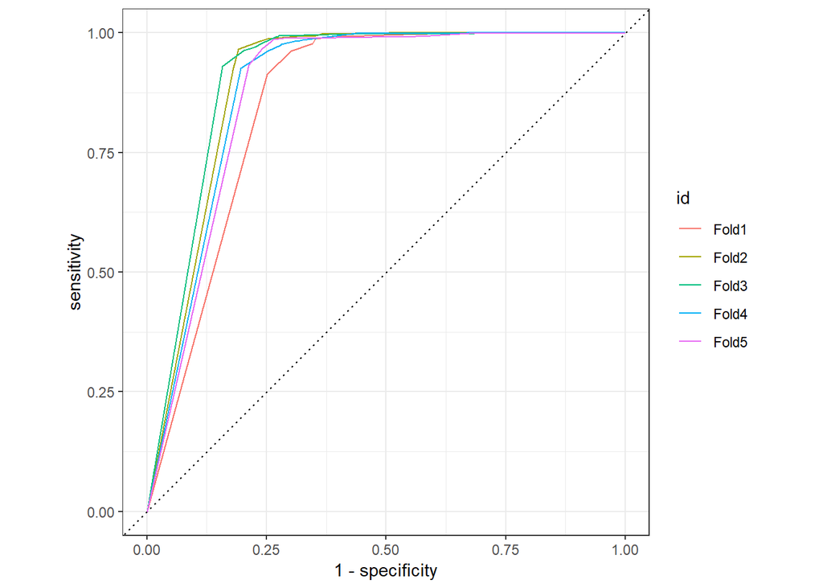

```r
rf_pred <-
  knn_res %>%
  collect_predictions()

rf_pred %>%
  group_by(id) %>% # id contains our folds
  roc_curve(BAD, .pred_0) %>%
  autoplot
```

#8:Neural network ##Specify model **The models failed**

```r
library(keras)

nnet_spec <-
  mlp() %>%
  set_mode("classification") %>%
  set_engine("keras", verbose = 0)
```

#Bundle recipe and model:

```r
nnet_wflow <-
 workflow() %>%
 add_recipe(dataset_rec) %>%
 add_model(nnet_spec)
```

#9.Compare models Extract metrics from our models to compare them:

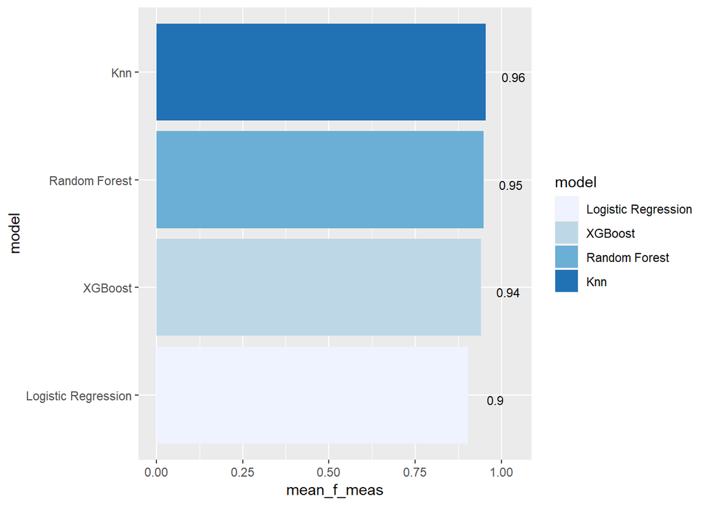

```r
library(forcats) #for fct_reorder function
log_metrics <-
  log_res %>%
  collect_metrics(summarise = TRUE) %>%
  mutate(model = "Logistic Regression") # add the name of the model to every row

rf_metrics <-
  rf_res %>%
  collect_metrics(summarise = TRUE) %>%
  mutate(model = "Random Forest")

xgb_metrics <-
  xgb_res %>%
  collect_metrics(summarise = TRUE) %>%
  mutate(model = "XGBoost")

knn_metrics <-
  knn_res %>%
  collect_metrics(summarise = TRUE) %>%
  mutate(model = "Knn")

# nnet_metrics <-
#   nnet_res %>%
#   collect_metrics(summarise = TRUE) %>%
#   mutate(model = "Neural Net")

# create dataframe with all models
model_compare <- bind_rows(
                          log_metrics,
                           rf_metrics,
                           xgb_metrics,
                           knn_metrics,
                         # nnet_metrics
                           )

# change data structure
model_comp <-
  model_compare %>%
  select(model, .metric, mean, std_err) %>%
  pivot_wider(names_from = .metric, values_from = c(mean, std_err))

# show mean F1-Score for every model
model_comp %>%
  arrange(mean_f_meas) %>%
  mutate(model = fct_reorder(model, mean_f_meas)) %>% # order results
  ggplot(aes(model, mean_f_meas, fill=model)) +
  geom_col() +
  coord_flip() +
  scale_fill_brewer(palette = "Blues") +
   geom_text(
     size = 3,
     aes(label = round(mean_f_meas, 2), y = mean_f_meas + 0.08),
     vjust = 1
  )
```

`OBSERVATION`:knn model performed best in our train set hence will be used on test set.

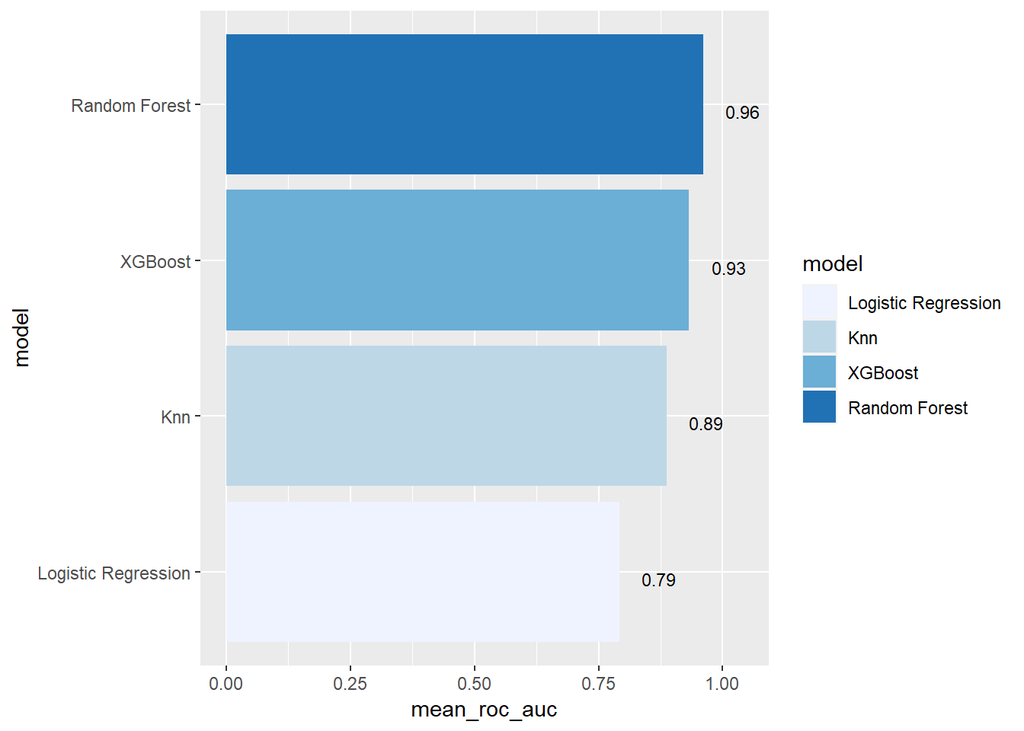

```r
# show mean area under the curve (auc) per model
model_comp %>%
  arrange(mean_roc_auc) %>%
  mutate(model = fct_reorder(model, mean_roc_auc)) %>%
  ggplot(aes(model, mean_roc_auc, fill=model)) +
  geom_col() +
  coord_flip() +
  scale_fill_brewer(palette = "Blues") +
     geom_text(
     size = 3,
     aes(label = round(mean_roc_auc, 2), y = mean_roc_auc + 0.08),
     vjust = 1
  )
```

Let’s find the maximum mean F1-Score:

```r
model_comp %>% slice_max(mean_f_meas)
```

| model | mean_accuracy | mean_f_meas | mean_kap | mean_precision | mean_recall | mean_roc_auc | mean_sens | mean_spec | std_err_accuracy | std_err_f_meas | std_err_kap | std_err_precision | std_err_recall | std_err_roc_auc | std_err_sens | std_err_spec |
| --- | --- | --- | --- | --- | --- | --- | --- | --- | --- | --- | --- | --- | --- | --- | --- | --- |
| Knn | 0.9254895 | 0.9552008 | 0.7356158 | 0.9214361 | 0.9916127 | 0.8872968 | 0.9916127 | 0.6600151 | 0.004646888 | 0.002694755 | 0.01872849 | 0.00496468 | 0.002212681 | 0.009072453 | 0.002212681 | 0.02324028 |

#10.Last evaluation on test set ##Knn

```r
last_fit_Knn <- last_fit(knn_wflow,
                        split = data_split,
                        metrics = metric_set(
                          recall, precision, f_meas,
                          accuracy, kap,
                          roc_auc, sens, spec)
                        )
```

#Show performance metrics

```r
last_fit_Knn %>%
  collect_metrics()
```

| .metric | .estimator | .estimate | .config |
| --- | --- | --- | --- |
| recall | binary | 0.9941324 | Preprocessor1_Model1 |
| precision | binary | 0.9229572 | Preprocessor1_Model1 |
| f_meas | binary | 0.9572236 | Preprocessor1_Model1 |
| accuracy | binary | 0.9289068 | Preprocessor1_Model1 |
| kap | binary | 0.7486098 | Preprocessor1_Model1 |
| sens | binary | 0.9941324 | Preprocessor1_Model1 |
| spec | binary | 0.6677852 | Preprocessor1_Model1 |
| roc_auc | binary | 0.8942222 | Preprocessor1_Model1 |

##rf

```r
last_fit_rf <- last_fit(rf_wflow,
                        split = data_split,
                        metrics = metric_set(
                          recall, precision, f_meas,
                          accuracy, kap,
                          roc_auc, sens, spec)
                        )
```

performance metrics

```r
last_fit_rf %>%
  collect_metrics()
```

| .metric | .estimator | .estimate | .config |
| --- | --- | --- | --- |
| recall | binary | 0.9790444 | Preprocessor1_Model1 |
| precision | binary | 0.9233202 | Preprocessor1_Model1 |
| f_meas | binary | 0.9503662 | Preprocessor1_Model1 |
| accuracy | binary | 0.9181757 | Preprocessor1_Model1 |
| kap | binary | 0.7186740 | Preprocessor1_Model1 |
| sens | binary | 0.9790444 | Preprocessor1_Model1 |
| spec | binary | 0.6744966 | Preprocessor1_Model1 |
| roc_auc | binary | 0.9575460 | Preprocessor1_Model1 |

# variable importance scores

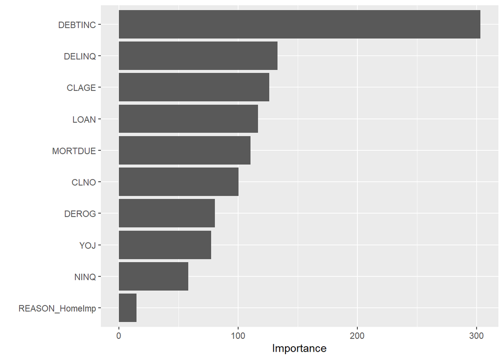

```r
library(vip)

last_fit_rf %>%
  pluck(".workflow", 1) %>%
  pull_workflow_fit() %>%
  vip(num_features = 10)
```

#confusion matrix for the final model;

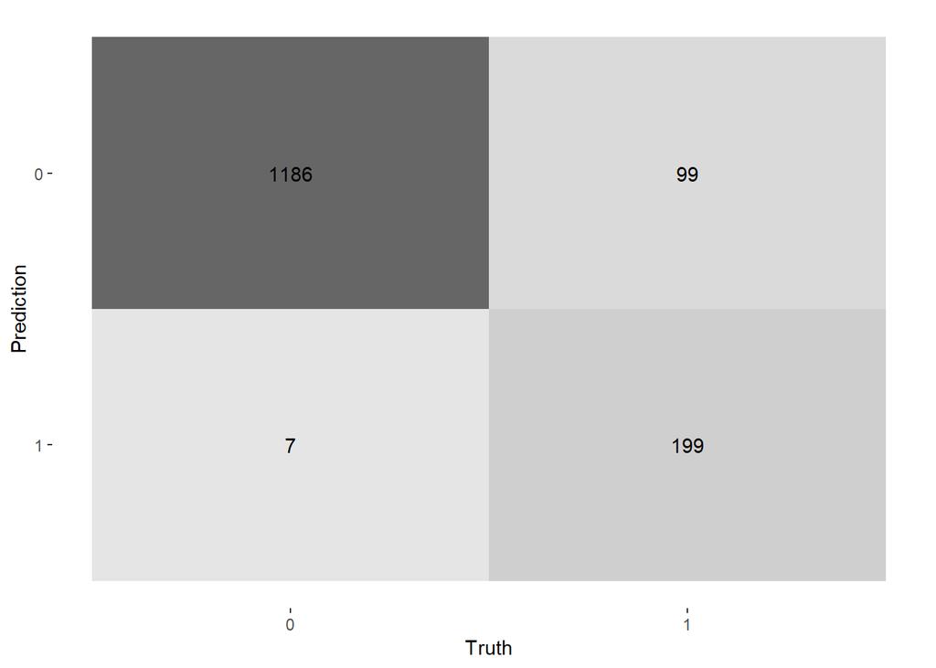

```r
last_fit_Knn %>%
  collect_predictions() %>%
  conf_mat(BAD, .pred_class) %>%
  autoplot(type = "heatmap")
```

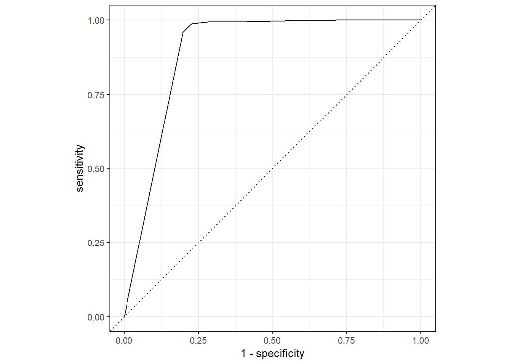

```r
last_fit_Knn %>%
  collect_predictions() %>%
  roc_curve(BAD, .pred_0) %>%
  autoplot()
```